# Regresión lineal múltiple: neodimio, lantano y samario

Unidad 3 · Regresión · Geoquímica de rocas con datos de EarthChem PetDB

Cristoffer Rumiguano, Ana Gabriela Fernández, Evelyn Bustamante, Jessica Haro, Jhonattan Ligña

Noviembre de 2026

> Proyecto estrictamente académico (Estadística y Probabilidades, FIGEMPA – UCE). Datos: EarthChem PetDB (CC BY 4.0), descargados el 13/10/2026. Web del proyecto: https://crisrumiguano-art.github.io/geoquimica-earthchem-ml/

## 1. Carga de datos

Se usa la base completa (159 760 análisis). Para cada par se toman solo las filas que tienen **los dos** datos: no se inventa ningún valor que falte.

```r
knitr::opts_chunk$set(echo = TRUE, message = FALSE, warning = FALSE, fig.align = "center")
if (!file.exists("data/earthchem_limpio.csv.gz")) {
  dir.create("data", showWarnings = FALSE)
  download.file("https://github.com/crisrumiguano-art/geoquimica-earthchem-ml/raw/main/data/earthchem_limpio.csv.gz", "data/earthchem_limpio.csv.gz", mode = "wb")
}
base <- read.csv(gzfile("data/earthchem_limpio.csv.gz", encoding = "UTF-8"), check.names = FALSE)
dim(base)
```

```
## [1] 159760     75
```

## 2. Asignación de variables

**y = Nd (ppm)**, explicada por **x1 = La (ppm)** y **x2 = Sm (ppm)**: el neodimio está entre el lantano y el samario en la serie de las tierras raras, así que debería poder estimarse con sus dos vecinos. Además se agrega una variable cualitativa, el ambiente tectónico, como **variable ficticia (dummy)**.

```r
datos <- data.frame(Nd = base[["Nd (ppm)"]], La = base[["La (ppm)"]], Sm = base[["Sm (ppm)"]],
                    grupo = base[["Tectonic Group"]])
datos <- na.omit(datos)                                # filas con todo completo
datos <- datos[datos$Nd > 0 & datos$La > 0 & datos$Sm > 0 & datos$grupo != "mixto", ]
nrow(datos)
```

```
## [1] 26765
```

## 3. Tabla de valores

```r
knitr::kable(head(datos, 10), caption = "Tabla N° 1: primeras 10 filas")
```

Tabla N° 1: primeras 10 filas

|  | Nd | La | Sm | grupo |
| --- | --- | --- | --- | --- |
| 2 | 0.470 | 0.180 | 0.190 | dorsal y corteza oceanica |
| 7 | 14.300 | 9.000 | 3.980 | margen convergente |
| 9 | 1.544 | 0.267 | 0.789 | dorsal y corteza oceanica |
| 19 | 6.750 | 1.480 | 2.340 | margen convergente |
| 21 | 12.770 | 8.750 | 3.810 | intraplaca y rift |
| 27 | 6.260 | 4.160 | 0.890 | dorsal y corteza oceanica |
| 35 | 10.190 | 5.340 | 3.100 | margen convergente |
| 38 | 11.400 | 6.650 | 3.410 | intraplaca y rift |
| 50 | 4.890 | 2.640 | 1.590 | intraplaca y rift |
| 62 | 15.820 | 10.790 | 3.930 | margen convergente |

## 4. Diagrama de dispersión y matriz de correlación

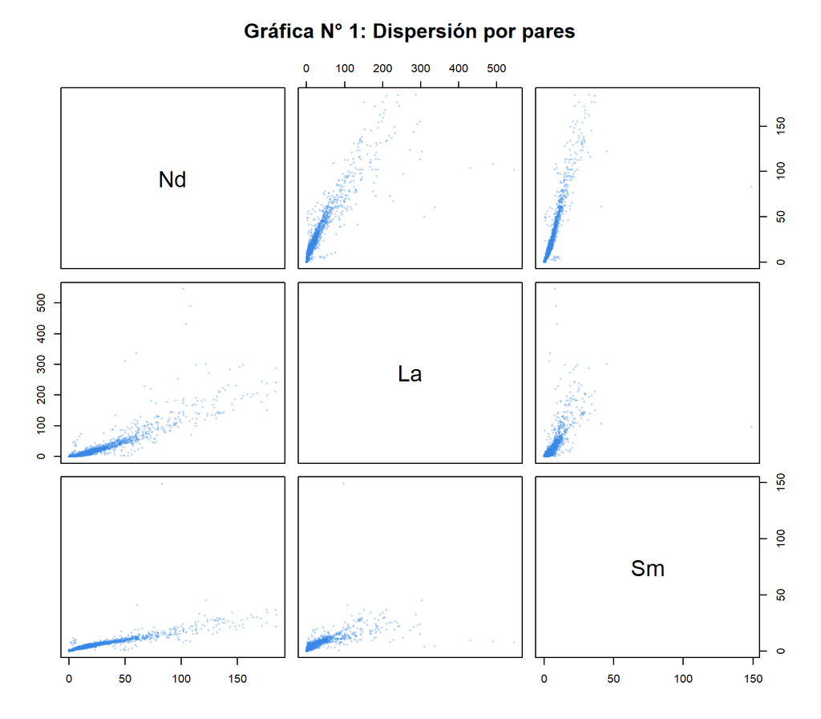

```r
set.seed(2026)
dibujo <- datos[sample(nrow(datos), 3000), c("Nd", "La", "Sm")]   # 3000 puntos para que se vea
dibujo <- dibujo[dibujo$Nd < quantile(datos$Nd, 0.995), ]          # sin el 0,5 % más extremo
pairs(dibujo, pch = 16, cex = 0.4, col = rgb(0.22, 0.53, 0.9, 0.3), main = "Gráfica N° 1: Dispersión por pares")
```

```r
R <- cor(datos[, c("Nd", "La", "Sm")])
knitr::kable(round(R, 3), caption = "Tabla N° 2: matriz de correlación")
```

Tabla N° 2: matriz de correlación

|  | Nd | La | Sm |
| --- | --- | --- | --- |
| Nd | 1.000 | 0.797 | 0.765 |
| La | 0.797 | 1.000 | 0.707 |
| Sm | 0.765 | 0.707 | 1.000 |

Las dos explicativas están muy correlacionadas entre sí (La–Sm r = 0.71): es **multicolinealidad**. No impide predecir, pero hace que los coeficientes por separado sean menos estables.

```r
r2_La_Sm <- summary(lm(La ~ Sm, data = datos))$r.squared
VIF <- 1 / (1 - r2_La_Sm)                              # factor de inflación de la varianza
VIF                                                    # más de 10 = multicolinealidad fuerte
```

```
## [1] 1.999439
```

## 5. Conjetura del modelo

Modelo lineal múltiple: y = a + b1·x1 + b2·x2. En forma matricial, β = (XᵀX)⁻¹·Xᵀy; `lm()` hace ese cálculo.

```r
modelo <- lm(Nd ~ La + Sm, data = datos)
coef(modelo)
```

```
## (Intercept)          La          Sm
##   1.7099733   0.3680367   2.4465774
```

```r
# El mismo cálculo con matrices:
X <- cbind(1, datos$La, datos$Sm)
beta <- solve(t(X) %*% X) %*% t(X) %*% datos$Nd
round(t(beta), 4)
```

```
##      [,1]  [,2]   [,3]
## [1,] 1.71 0.368 2.4466
```

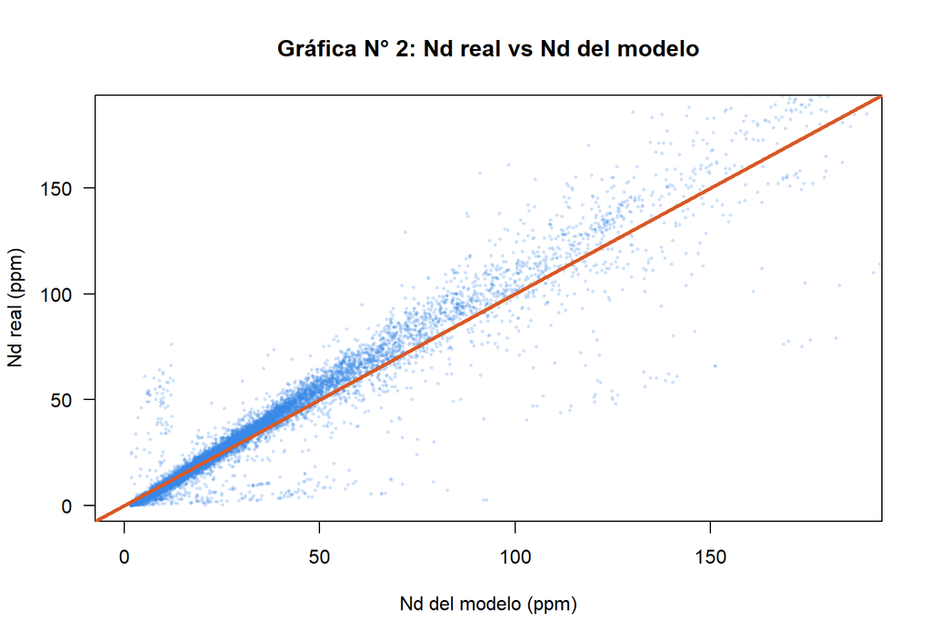

```r
predicho <- predict(modelo)
plot(predicho, datos$Nd, pch = 16, cex = 0.4, col = rgb(0.22, 0.53, 0.9, 0.25), las = 1,
     xlim = c(0, quantile(datos$Nd, 0.995)), ylim = c(0, quantile(datos$Nd, 0.995)),   # zoom al 99,5 %
     main = "Gráfica N° 2: Nd real vs Nd del modelo", xlab = "Nd del modelo (ppm)", ylab = "Nd real (ppm)")
abline(a = 0, b = 1, col = "#d95926", lwd = 3)
```

```r
modelo_dummy <- lm(Nd ~ La + Sm + grupo, data = datos)
round(coef(modelo_dummy), 4)
```

```
##                    (Intercept)                             La
##                         0.8153                         0.3664
##                             Sm grupodorsal y corteza oceanica
##                         2.4358                        -0.0883
##         grupointraplaca y rift        grupomargen convergente
##                         1.4272                         1.6127
```

```r
c(R2_sin_dummy = summary(modelo)$r.squared, R2_con_dummy = summary(modelo_dummy)$r.squared)
```

```
## R2_sin_dummy R2_con_dummy
##    0.7166281    0.7169916
```

## 6. Test de aprobación

```r
R2 <- summary(modelo)$r.squared * 100
r <- sqrt(R2 / 100)                                    # correlación múltiple
knitr::kable(data.frame(modelo = "múltiple", R = round(r, 4), R2_porcentaje = round(R2, 2)),
             caption = "Tabla N° 3: test de aprobación")
```

Tabla N° 3: test de aprobación

| modelo | R | R2_porcentaje |
| --- | --- | --- |
| múltiple | 0.8465 | 71.66 |

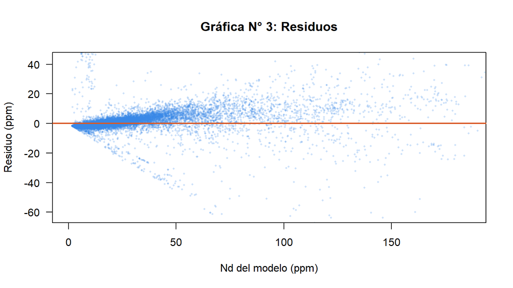

```r
plot(predicho, residuals(modelo), pch = 16, cex = 0.4, col = rgb(0.22, 0.53, 0.9, 0.25), las = 1,
     xlim = c(0, quantile(datos$Nd, 0.995)), ylim = quantile(residuals(modelo), c(0.0025, 0.9975)),
     main = "Gráfica N° 3: Residuos", xlab = "Nd del modelo (ppm)", ylab = "Residuo (ppm)")
abline(h = 0, col = "#d95926", lwd = 2)
```

## 7. Restricciones

Las concentraciones son positivas: el modelo vale dentro del rango medido de La y Sm, y para combinaciones que existen en la naturaleza (La y Sm suben juntos; un La muy alto con Sm muy bajo no se da).

```r
sapply(datos[, c("La", "Sm")], range)
```

```
##             La       Sm
## [1,]    0.0001 8.01e-05
## [2,] 2337.0000 2.90e+02
```

## 8. Estimación de pronósticos

**Si una roca tiene 20 ppm de La y 5 ppm de Sm, ¿cuánto Nd se espera?**

```r
nuevo <- data.frame(La = 20, Sm = 5)
y0 <- predict(modelo, nuevo)
y0
```

```
##        1
## 21.30359
```

## 9. Conclusión

El Nd se representa con un **modelo lineal múltiple**: y = 1.71 + 0.368·x1 + 2.447·x2, donde x1 es La y x2 es Sm. El modelo explica el 71.7 % de la variación del Nd. Para La = 20 ppm y Sm = 5 ppm se espera Nd ≈ 21.3 ppm. Agregar el ambiente tectónico como variable ficticia casi no mejora el ajuste: las tierras raras se mueven juntas en cualquier ambiente.